# Vidushi_18200009_Assignment1

## Data Science In Python- Assignment 1

### Student Name- Vidushi Jain

### Student Number- 18200009

These are some additional package that we need to install to run this notebook. Wordcloud is used to create wordcloud image. VaderSentiment is used to do sentiment analysis of reviews. Squarify is used to create TreeMap.

```python
!pip install wordcloud
!pip install vaderSentiment
!pip install squarify
```

All import statements required to run the notebook

```python
import os
import urllib.request
import csv
import pandas as pd
import sys,socket
import requests
import math
import json
import numpy as np
from bs4 import BeautifulSoup
import re
import seaborn as sns
from wordcloud import WordCloud
from vaderSentiment.vaderSentiment import SentimentIntensityAnalyzer
import squarify
import matplotlib
import matplotlib.pyplot as plt
from matplotlib import style
from nltk.corpus import stopwords
import nltk
%matplotlib inline
```

Below command is used to display the complete value for each column

```python
pd.set_option('display.max_colwidth', -1)
```

### Please Note- You can run this notebook from Task 3 directly as I have already collected the data and stored them in the form of CSV and JSON files</b>

## 1. Task - Choose one or more suitable web API¶

I have used **Zomato API** for this assignment.

- Zomato API is used using an API key to analyze and compare restaurants of Dublin. The API key is **53731a7e2eb6195ed6a58eaf0e4f6b31**
- Below are the **limitation** of using this API
- We can make only up to 1000 calls/day
- We can get up to 100 restaurants details by changing the 'start' and 'count' parameters with the maximum value of count being 20. To overcome this limitation, I have fetched data on the basis of all the cuisines available in dublin. By doing so, I was able to get data for **1927 unique resturants**
- In the basic API plan, we can get only 5 reviews for each restaurants. Also, these reviews are not complete, we only get first 150 characters of each review. I have done the analysis using this available data. I have **5463 reviews** in the dataset
- I have used Web Scrapping using BeautifulSoup to fetch highlights of each restaurant. Highlights refer to the services which the restuarant provide like Indoor Seating, Takeaway, Breakfast etc.

**I am analyzing data only for Dublin whose city_id is 91 in Zomato Database. I have used longitude(-6.248889) and latitude(53.333056) value to find the id**

```python
api_key = "53731a7e2eb6195ed6a58eaf0e4f6b31"
```

This variable is used to keep track of API calls. Since we can make only 1000 API calls per day. So we need to run different block of codes on different days to collect the day. If you get the message saying" Number of API Request exceeded. Please try next day by resetting api_count variable to zero", then please run the below command again and try running the code of next day.

```python
api_count=0
```

## 2. Task - Collecting data from One or more choosen Web API(s) and storing the JSON response in the file

**To use Zomato API we have a restriction that only 1000 calls can be made in a day. So I have collected the data on three different daya and stored the JSON file in the folders to use it later.**

### Fetching Data for Categories

Getting Data From API Request and writing the response in the file

```python
if api_count <= 1000:
    categories_request = requests.get('https://developers.zomato.com/api/v2.1/categories',
                                  headers={'Accept':'application/json','user-key':'53731a7e2eb6195ed6a58eaf0e4f6b31'})
    api_count=api_count+1
else:
    print("Number of API Request exceeded. Please try next day by resetting api_count variable to zero")

try:
    file_name='categories.json'
    file = open(file_name, "w")
    file.write(categories_request.text)
    file.close()
except Exception as h:
    print("Cannot write to file \nError:"+str(h))
```

### Fetching Data for Cuisines

Getting Data From API Request and writing the response in the file

```python
if api_count <= 1000:
    cuisines_request = requests.get('https://developers.zomato.com/api/v2.1/cuisines?city_id=91',
                                headers={'Accept':'application/json','user-key':'53731a7e2eb6195ed6a58eaf0e4f6b31'})
    api_count=api_count+1
else:
    print("Number of API Request exceeded. Please try next day by resetting api_count variable to zero")

try:
    file_name='cuisines.json'
    file = open(file_name, "w")
    file.write(cuisines_request.text)
    file.close()
except Exception as h:
    print("Cannot write to file \nError:"+str(h))
```

**I am reading and writing the cuisines data in a dataset, as I would be needing it to fetch restuarants data**

```python
with open('cuisines.json') as cuisines_json:
    cuisines = json.load(cuisines_json)
    cuisines = cuisines['cuisines']
    cuisines_list = []
    for cuisine in cuisines:
        cuisines_list.append([cuisine['cuisine']['cuisine_id'],cuisine['cuisine']['cuisine_name']])

cuisines_dataset = pd.DataFrame(cuisines_list)
cuisines_dataset.columns = ['cuisine_id','cuisine_name']
cuisines_dataset.head()
```

|  | cuisine_id | cuisine_name |
| --- | --- | --- |
| 0 | 152 | African |
| 1 | 1 | American |
| 2 | 151 | Argentine |
| 3 | 3 | Asian |
| 4 | 131 | Australian |

```python
export_csv = cuisines_dataset.to_csv (r'cuisines_dataset.csv', index = None, header=True)
```

### Fetching Data for Establishments

Getting list of restaurant types from API Request and writing the response in the file

```python
if api_count <= 1000:
    establishments_request = requests.get('https://developers.zomato.com/api/v2.1/establishments?city_id=91',\
                                      headers={'Accept':'application/json','user-key':'53731a7e2eb6195ed6a58eaf0e4f6b31'})
    api_count=api_count+1
else:
    print("Number of API Request exceeded. Please try next day by resetting api_count variable to zero")

try:
    file_name='establishments.json'
    file = open(file_name, "w")
    file.write(establishments_request.text)
    file.close()
except Exception as h:
    print("Cannot write to file \nError:"+str(h))
```

### Fetching Data for Restaurants

We can get up to 100 restaurants details by changing the 'start' and 'count' parameters with the maximum value of count being 20. To overcome this limitation, I have fetched the data on the basis of all the 68 cuisines available in Dublin. By doing so, I was able to get data for **1927 unique resturants** Also for each cuisines, we can get maximum 100 restaurants. So I am running the loop 5 times and at each iteration, I am changing the value of start to fetch 20 new records from new starting point. If there are less restaurants for a cuisine, in that case I am checking the results value. If there are no more restaurants for that cuisine, then I am breaking out of the loop. This will prevent unnecessary API calls.  
**Please Note**  
In the below code, we are saving all the JSON files in restaurants folder. If you run the below command, all the files will be saved in that location. For the further analysis please use **restaurants_data** folder, as that will have all the data which was collected on various days.

```python
for cuisine_id in cuisines_dataset['cuisine_id']:
    count =0
    start=0
    while count < 5:
        if api_count <= 1000:
            link='https://developers.zomato.com/api/v2.1/search?start=%d&count=20&lat=53.333056&lon=-6.248889&cuisines=%d' % (start,cuisine_id)
            restro_results=requests.get(link,headers={'Accept':'application/json','user-key':'53731a7e2eb6195ed6a58eaf0e4f6b31'})
            api_count=api_count+1
            restro_json=restro_results.json()
            results = restro_json['results_shown']
            if(results == 0):
                break;
            else:
                try:
                    file_name='%d_%d.json'% (cuisine_id,count)
                    file_name=os.path.join(os.getcwd(),'restaurants',file_name)
                    file = open(file_name, "w")
                    file.write(restro_results.text)
                    file.close()
                    start = start+20
                    count += 1
                except Exception as h:
                    print("Cannot write to file \nError:"+str(h))
        else:
            print("Number of API Request exceeded. Please try next day by resetting api_count variable to zero")
            break; #this will come out of while loop

    if(api_count > 1000):
        print("Number of API Request exceeded. Please try next day by resetting api_count variable to zero")
        break #this is coming out of for loop
```

**I am reading all the JSON files from the restaurants folder and storing the relevant data in the dataset. I would be needing it to fetch reviews and also to do Web Scrapping for each restaurant**

```python
# All the json files are stored in this location
path_to_json = './restaurants_data/'
#finding only the json files
json_files = [pos_json for pos_json in os.listdir(path_to_json) if pos_json.endswith('.json')]

#Storing the restaurant data in the list
restaurants_list =[]

for index, js in enumerate(json_files):
    with open(os.path.join(path_to_json, js)) as json_file:
        #loading the json file
        restro = json.load(json_file)
        restaurants = restro['restaurants']
        #Reading the relevant fields from the JSON file
        for restaurant in restaurants:
            restaurants_list.append([restaurant['restaurant']['id'],restaurant['restaurant']['name'],restaurant['restaurant']['url'],
                                restaurant['restaurant']['location']['address'],restaurant['restaurant']['location']['locality'],
                                restaurant['restaurant']['location']['city'],restaurant['restaurant']['location']['city_id'],
                                restaurant['restaurant']['location']['latitude'],restaurant['restaurant']['location']['longitude'],
                                restaurant['restaurant']['location']['zipcode'],restaurant['restaurant']['location']['country_id'],
                                restaurant['restaurant']['location']['locality_verbose'],restaurant['restaurant']['cuisines'],
                                restaurant['restaurant']['average_cost_for_two'],restaurant['restaurant']['user_rating']['aggregate_rating'],
                                restaurant['restaurant']['user_rating']['rating_text'],restaurant['restaurant']['user_rating']['votes'],
                                restaurant['restaurant']['has_online_delivery'],restaurant['restaurant']['is_table_reservation_supported'],
                                restaurant['restaurant']['establishment_types']])


#Creating the Dataframe from the restaurants_list
restaurants_dataset = pd.DataFrame(restaurants_list)
#Defin
restaurants_dataset.columns = ['restaurant_id','restaurant_name','url','address','locality','city','city_id','latitude','longitude','zipcode',
                               'country_id','locality_verbose','cuisines','average_cost_for_two','aggregate_rating','rating_text',
                               'votes','has_online_delivery','is_table_reservation_supported','establishment_types']
```

Our Restaurants Dataset is ready

```python
restaurants_dataset.head()
```

|  | restaurant_id | restaurant_name | url | address | locality | city | city_id | latitude | longitude | zipcode | country_id | locality_verbose | cuisines | average_cost_for_two | aggregate_rating | rating_text | votes | has_online_delivery | is_table_reservation_supported | establishment_types |
| --- | --- | --- | --- | --- | --- | --- | --- | --- | --- | --- | --- | --- | --- | --- | --- | --- | --- | --- | --- | --- |
| 0 | 9100081 | Chillout Break Cafe | https://www.zomato.com/dublin/chillout-break-cafe-north-city?utm_source=api_basic_user&utm_medium=api&utm_campaign=v2.1 | 11 Moore Street, Dublin Dublin 1 | North City | Dublin | 91 | 53.3502083333 | -6.2623861111 | Dublin 1 | 97 | North City, Dublin | Polish, Cafe | 25 | 0 | Not rated | 1 | 0 | 0 | [] |
| 1 | 16522498 | Lituanica | https://www.zomato.com/dublin/lituanica-north-city?utm_source=api_basic_user&utm_medium=api&utm_campaign=v2.1 | Moore Street Mall, 58-66 Moore Street, Dublin Dublin 1 | Moore Street Mall, City Centre North | Dublin | 91 | 53.3512583333 | -6.2631555556 | Dublin 1 | 97 | Moore Street Mall, City Centre North, Dublin | Polish | 25 | 0 | Not rated | 0 | 0 | 0 | [] |
| 2 | 9100611 | The Really Old Sweet Shop | https://www.zomato.com/dublin/the-really-old-sweet-shop-malahide?utm_source=api_basic_user&utm_medium=api&utm_campaign=v2.1 | Kilronan House, Church Road, Malahide, Dublin Co. Dublin | Malahide | Dublin | 91 | 53.4502670015 | -6.1533546075 |  | 97 | Malahide, Dublin | Ice Cream, Desserts | 10 | 0 | Not rated | 2 | 0 | 0 | [] |
| 3 | 18229148 | Jinny Joe's Dublin | https://www.zomato.com/dublin/jinny-joes-dublin-crumlin?utm_source=api_basic_user&utm_medium=api&utm_campaign=v2.1 | 2 Herberton Road, Crumlin, Dublin 12 | Crumlin | Dublin | 91 | 53.3306200000 | -6.2978960000 | 12 | 97 | Crumlin, Dublin | Crepes, Ice Cream | 10 | 0 | Not rated | 1 | 0 | 0 | [] |
| 4 | 16518657 | Eileen's Cafe | https://www.zomato.com/dublin/eileens-cafe-howth?utm_source=api_basic_user&utm_medium=api&utm_campaign=v2.1 | Unit 1 Island View, Howth, Co. Dublin | Howth | Dublin | 91 | 53.3877916667 | -6.0672166667 |  | 97 | Howth, Dublin | Ice Cream, Crepes, Cafe | 20 | 0 | Not rated | 1 | 0 | 0 | [] |

Exporting the Restaurant Dataset in a csv file

```python
export_csv = restaurants_dataset.to_csv (r'restaurants_dataset.csv', index = None, header=True)
```

### Fetching More Info data for each Restaurant using Web Scrapping

[figure not shown]

**Please Note that this will take around 15-20 mins to run as we have around 2000 restaurants and we need to do scrapping for each one of them**

```python
highlight=[]
count=0;
process_count=100;
#Iterating through the restaurants_dataset
for index, row in restaurants_dataset.iterrows():
    restaurant_id=row["restaurant_id"]
    url=row["url"]
    headers = {'User-Agent': 'Mozilla/5.0 (Macintosh; Intel Mac OS X 10_11_6) AppleWebKit/537.36 (KHTML, like Gecko) Chrome/61.0.3163.100 Safari/537.36'}
    response = requests.get(url,headers=headers)
    content = response.content
    soup = BeautifulSoup(content,"html.parser")
    rest_highlights = soup.find_all("div",attrs={"class": "res-info-highlights"})
    #To iterate through each highlight or more info of a particular restaurant
    for EachHighlight in rest_highlights[0].select('div[class*="clearfix mb5"]'):
        iconText=EachHighlight.find("i")
        if 'red' in iconText['class']:
            icon="Not Present"
        elif 'green' in iconText['class']:
            icon="Present"
        text=EachHighlight.find("div").text
        highlight.append([restaurant_id,text,icon])
    count=count+1
    if (count == process_count):
        text="Web Scrapping done for %d restaurants"%(count)
        print(text)
        process_count = process_count+100
```

```
Web Scrapping done for 100 restaurants
Web Scrapping done for 200 restaurants
Web Scrapping done for 300 restaurants
Web Scrapping done for 400 restaurants
Web Scrapping done for 500 restaurants
Web Scrapping done for 600 restaurants
Web Scrapping done for 700 restaurants
Web Scrapping done for 800 restaurants
Web Scrapping done for 900 restaurants
Web Scrapping done for 1000 restaurants
Web Scrapping done for 1100 restaurants
Web Scrapping done for 1200 restaurants
Web Scrapping done for 1300 restaurants
Web Scrapping done for 1400 restaurants
Web Scrapping done for 1500 restaurants
Web Scrapping done for 1600 restaurants
Web Scrapping done for 1700 restaurants
Web Scrapping done for 1800 restaurants
Web Scrapping done for 1900 restaurants
```

```python
restaurant_feature_dataset = pd.DataFrame(highlight)
restaurant_feature_dataset.columns = ['restaurant_id','Highlights','Present/NotPresent']
restaurant_feature_dataset.head()
```

|  | restaurant_id | Highlights | Present/NotPresent |
| --- | --- | --- | --- |
| 0 | 9100081 | Takeaway Available | Present |
| 1 | 9100081 | Indoor Seating | Present |
| 2 | 16522498 | Takeaway Available | Present |
| 3 | 16522498 | Indoor Seating | Present |
| 4 | 9100611 | Takeaway Available | Present |

Exporting the resulting dataset in a csv file

```python
export_csv = restaurant_feature_dataset.to_csv (r'restaurant_feature_dataset.csv', index = None, header=True)
```

### Fetching Reviews of each Restaurant

In the basic API plan, we can get only 5 reviews for each restaurants. Also, these reviews are not complete, we only get first 150 characters of each review. I have done the analysis using this available data. I have **5463 reviews** in the dataset. We have to run the below code on two separate days to get the entire data for analysis. You can change the number of rows while selecting restaurant_id_list. On day 1, you can fetch for restaurants_dataset['restaurant_id'][:950] and on second day you can change the parameter to restaurants_dataset['restaurant_id'][950:1928]. By doing so you will get complete dataset.  
**Please Note**  
In the below code, we are saving all the JSON files in reviews folder. If you run the below command, all the files will be saved in that location. For the further analysis please use **reviews_data** folder, as that will have all the data which was collected on various days.

```python
restaurant_id_list = restaurants_dataset['restaurant_id'][950:1928]
for restaurant_id in restaurant_id_list :
    if api_count <= 1000:
        link='https://developers.zomato.com/api/v2.1/reviews?res_id=%s' % (restaurant_id)
        review_request=requests.get(link,headers={'Accept':'application/json','user-key':'53731a7e2eb6195ed6a58eaf0e4f6b31'})
        api_count=api_count+1
        try:
            file_name='%s.json'% (restaurant_id)
            file_name=os.path.join(os.getcwd(),'reviews',file_name)
            file = open(file_name, "w")
            file.write(review_request.text)
            file.close()
        except Exception as h:
                    print("Cannot write to file \nError:"+str(h))
    else:
        print("Number of API Request exceeded. Please try next day by resetting api_count variable to zero")
        break #this will come out of for loop
```

**You can directly run the below code. As all the data have been collected and stored in the form of CSV and JSON files**

## 3. Task- Parse the collected data, and store it in an appropriate file format for subsequent analysis (e.g. plain text, JSON, XML, CSV).

**Please Note**  
**I have stored the data files in reviews_data and restaurants_data folder. Below code will read the collected data and create dataframes with relevant information**

### Reading the cuisines.json file and parsing the relevant information it to store it in the dataframe

```python
with open('cuisines.json') as cuisines_json:
    cuisines = json.load(cuisines_json)
    cuisines = cuisines['cuisines']
    cuisines_list = []
    for cuisine in cuisines:
        cuisines_list.append([cuisine['cuisine']['cuisine_id'],cuisine['cuisine']['cuisine_name']])

cuisines_dataset = pd.DataFrame(cuisines_list)
cuisines_dataset.columns = ['cuisine_id','cuisine_name']
cuisines_dataset.head()
```

|  | cuisine_id | cuisine_name |
| --- | --- | --- |
| 0 | 152 | African |
| 1 | 1 | American |
| 2 | 151 | Argentine |
| 3 | 3 | Asian |
| 4 | 131 | Australian |

```python
export_csv = cuisines_dataset.to_csv (r'cuisines_dataset.csv', index = None, header=True)
```

### Reading the **categories.json** file and parsing the relevant information it to store it in the dataframe

```python
with open('categories.json') as json_file:
    categories = json.load(json_file)
    categories = categories['categories']
    categories_list = []
    for category in categories:
        categories_list.append([category['categories']['id'],category['categories']['name']])

categories_dataset = pd.DataFrame(categories_list)
categories_dataset.columns = ['ID','Name']
categories_dataset
```

|  | ID | Name |
| --- | --- | --- |
| 0 | 1 | Delivery |
| 1 | 2 | Dine-out |
| 2 | 3 | Nightlife |
| 3 | 4 | Catching-up |
| 4 | 5 | Takeaway |
| 5 | 6 | Cafes |
| 6 | 7 | Daily Menus |
| 7 | 8 | Breakfast |
| 8 | 9 | Lunch |
| 9 | 10 | Dinner |
| 10 | 11 | Pubs & Bars |
| 11 | 13 | Pocket Friendly Delivery |
| 12 | 14 | Clubs & Lounges |

Exporting the resulting dataset in the csv file

```python
export_csv = categories_dataset.to_csv (r'categories_dataset.csv', index = None, header=True)
```

### Reading the **establishments.json** file and parsing the relevant information to store it in the dataframe

```python
with open('establishments.json') as establishments_json:
    establishments = json.load(establishments_json)
    establishments = establishments['establishments']
    establishments_list = []
    for establishment in establishments:
        establishments_list.append([establishment['establishment']['id'],establishment['establishment']['name']])

establishments_dataset = pd.DataFrame(establishments_list)
establishments_dataset.columns = ['establishment_id','establishment_name']
establishments_dataset.head()
```

|  | establishment_id | establishment_name |
| --- | --- | --- |
| 0 | 20 | Food Court |
| 1 | 21 | Quick Bites |
| 2 | 1 | Café |
| 3 | 16 | Casual Dining |
| 4 | 6 | Pub |

Exporting the resulting dataset in the csv file

```python
export_csv = establishments_dataset.to_csv (r'establishments_dataset.csv', index = None, header=True)
```

### Reading the restaurants json files and parsing the relevant information to store it in the dataframe

All the restaurants json files was collected and stored in restaurants_data folder. I am reading each file and parsing the relevant information from each file and storing the data in the dataframe

```python
# All the json files are stored in this location
path_to_json = './restaurants_data/'
#finding only the json files
json_files = [pos_json for pos_json in os.listdir(path_to_json) if pos_json.endswith('.json')]

#Storing the restaurant data in the list
restaurants_list =[]

for index, js in enumerate(json_files):
    with open(os.path.join(path_to_json, js)) as json_file:
        #loading the json file
        restro = json.load(json_file)
        restaurants = restro['restaurants']
        #Reading the relevant fields from the JSON file
        for restaurant in restaurants:
            restaurants_list.append([restaurant['restaurant']['id'],restaurant['restaurant']['name'],restaurant['restaurant']['url'],
                                restaurant['restaurant']['location']['address'],restaurant['restaurant']['location']['locality'],
                                restaurant['restaurant']['location']['city'],restaurant['restaurant']['location']['city_id'],
                                restaurant['restaurant']['location']['latitude'],restaurant['restaurant']['location']['longitude'],
                                restaurant['restaurant']['location']['zipcode'],restaurant['restaurant']['location']['country_id'],
                                restaurant['restaurant']['location']['locality_verbose'],restaurant['restaurant']['cuisines'],
                                restaurant['restaurant']['average_cost_for_two'],restaurant['restaurant']['user_rating']['aggregate_rating'],
                                restaurant['restaurant']['user_rating']['rating_text'],restaurant['restaurant']['user_rating']['votes'],
                                restaurant['restaurant']['has_online_delivery'],restaurant['restaurant']['is_table_reservation_supported'],
                                restaurant['restaurant']['establishment_types']])


#Creating the Dataframe from the restaurants_list
restaurants_dataset = pd.DataFrame(restaurants_list)
#Defin
restaurants_dataset.columns = ['restaurant_id','restaurant_name','url','address','locality','city','city_id','latitude','longitude','zipcode',
                               'country_id','locality_verbose','cuisines','average_cost_for_two','aggregate_rating','rating_text',
                               'votes','has_online_delivery','is_table_reservation_supported','establishment_types']
```

```python
restaurants_dataset.head()
```

|  | restaurant_id | restaurant_name | url | address | locality | city | city_id | latitude | longitude | zipcode | country_id | locality_verbose | cuisines | average_cost_for_two | aggregate_rating | rating_text | votes | has_online_delivery | is_table_reservation_supported | establishment_types |
| --- | --- | --- | --- | --- | --- | --- | --- | --- | --- | --- | --- | --- | --- | --- | --- | --- | --- | --- | --- | --- |
| 0 | 9100081 | Chillout Break Cafe | https://www.zomato.com/dublin/chillout-break-cafe-north-city?utm_source=api_basic_user&utm_medium=api&utm_campaign=v2.1 | 11 Moore Street, Dublin Dublin 1 | North City | Dublin | 91 | 53.3502083333 | -6.2623861111 | Dublin 1 | 97 | North City, Dublin | Polish, Cafe | 25 | 0 | Not rated | 1 | 0 | 0 | [] |
| 1 | 16522498 | Lituanica | https://www.zomato.com/dublin/lituanica-north-city?utm_source=api_basic_user&utm_medium=api&utm_campaign=v2.1 | Moore Street Mall, 58-66 Moore Street, Dublin Dublin 1 | Moore Street Mall, City Centre North | Dublin | 91 | 53.3512583333 | -6.2631555556 | Dublin 1 | 97 | Moore Street Mall, City Centre North, Dublin | Polish | 25 | 0 | Not rated | 0 | 0 | 0 | [] |
| 2 | 9100611 | The Really Old Sweet Shop | https://www.zomato.com/dublin/the-really-old-sweet-shop-malahide?utm_source=api_basic_user&utm_medium=api&utm_campaign=v2.1 | Kilronan House, Church Road, Malahide, Dublin Co. Dublin | Malahide | Dublin | 91 | 53.4502670015 | -6.1533546075 |  | 97 | Malahide, Dublin | Ice Cream, Desserts | 10 | 0 | Not rated | 2 | 0 | 0 | [] |
| 3 | 18229148 | Jinny Joe's Dublin | https://www.zomato.com/dublin/jinny-joes-dublin-crumlin?utm_source=api_basic_user&utm_medium=api&utm_campaign=v2.1 | 2 Herberton Road, Crumlin, Dublin 12 | Crumlin | Dublin | 91 | 53.3306200000 | -6.2978960000 | 12 | 97 | Crumlin, Dublin | Crepes, Ice Cream | 10 | 0 | Not rated | 1 | 0 | 0 | [] |
| 4 | 16518657 | Eileen's Cafe | https://www.zomato.com/dublin/eileens-cafe-howth?utm_source=api_basic_user&utm_medium=api&utm_campaign=v2.1 | Unit 1 Island View, Howth, Co. Dublin | Howth | Dublin | 91 | 53.3877916667 | -6.0672166667 |  | 97 | Howth, Dublin | Ice Cream, Crepes, Cafe | 20 | 0 | Not rated | 1 | 0 | 0 | [] |

```python
export_csv = restaurants_dataset.to_csv (r'restaurants_dataset.csv', index = None, header=True)
```

### Reading the reviews json files and parsing the relevant information to store it in the dataframe

All the review json files was collected and stored in reviews_data folder. I am reading each file and parsing the relevant information from each file and storing the data in the dataframe.

```python
#Folder Location where all the JSON files are stored
path_to_json = './reviews_data/'
#Finding only the JSON files
json_files = [pos_json for pos_json in os.listdir(path_to_json) if pos_json.endswith('.json')]

reviews_list = []
for index, js in enumerate(json_files):
    with open(os.path.join(path_to_json, js)) as json_file:
        #Reading the JSON file
        reviews = json.load(json_file)
        reviews = reviews['user_reviews']
        #Fetching the restaurant_id from the file name
        restaurant_id=js[:-5]
        for review in reviews:
            reviews_list.append([restaurant_id,review['review']['rating'],review['review']['review_text'],
                                review['review']['id'],review['review']['rating_text'],
                                review['review']['likes'],review['review']['user']['name'],
                                review['review']['user']['foodie_level'],review['review']['user']['foodie_level_num'],
                                review['review']['comments_count']])


#creating the dataframe
reviews_dataset = pd.DataFrame(reviews_list)
reviews_dataset.columns = ['restaurant_id','review_rating','review_text','review_id','rating_text','likes',
                           'username','user_foodie_level','user_foodie_level_num','comments_count']
reviews_dataset.head()
```

|  | restaurant_id | review_rating | review_text | review_id | rating_text | likes | username | user_foodie_level | user_foodie_level_num | comments_count |
| --- | --- | --- | --- | --- | --- | --- | --- | --- | --- | --- |
| 0 | 9100412 | 1.0 | We ordered a pizza meal, and it didnt arrived. We rang to claim and they said they were going to send it back. It never came. We waited for ... | 26147540 | Avoid! | 0 | Juan Paleo | Foodie | 2 | 0 |
| 1 | 9100412 | 1.0 | NEVER AGAIN!!! Ordered my pizza online using the website at 19:45 and was so disappointing. Online gave option of selecting toppings with a ... | 25440914 | Avoid! | 0 | Fiona B | Foodie | 2 | 0 |
| 2 | 18372847 | 4.0 | Good buffet... Been there a few times with friends. Good staffs and plenty of options to choose from. Desert section needs some improvisatio... | 40108317 | Great! | 0 | Danny Joseph Sequeira | Big Foodie | 4 | 0 |
| 3 | 18372847 | 1.0 | I chose the reaturant as a Bday lunch for my wife. But sad to say, One of the worst and worst experience in my life choosing this restaurant... | 39659350 | Avoid! | 0 | @jack | Big Foodie | 4 | 0 |
| 4 | 18372847 | 3.0 | Good food. Average quality. It would be better if the quality of desserts was more focused on than the variety. Very few vegetarian options.... | 35078916 | Average | 8 | Kashish Verma | Big Foodie | 5 | 0 |

Exporting the resulting dataset in the csv file

```python
export_csv = reviews_dataset.to_csv (r'reviews_dataset.csv', index = None, header=True)
```

### Reading the restaurant_feature_dataset.csv file and storing the content in the dataframe

```python
restaurant_feature_dataset=pd.read_csv("restaurant_feature_dataset.csv",\
               dtype={"restaurant_id": object, "Highlights": object,"Present/NotPresent" : object})
```

```python
restaurant_feature_dataset.head()
```

|  | restaurant_id | Highlights | Present/NotPresent |
| --- | --- | --- | --- |
| 0 | 9100081 | Takeaway Available | Present |
| 1 | 9100081 | Indoor Seating | Present |
| 2 | 16522498 | Takeaway Available | Present |
| 3 | 16522498 | Indoor Seating | Present |
| 4 | 9100611 | Takeaway Available | Present |

## 4. Task- Load and represent the data using an appropriate data structure (i.e. records/ items as rows, described by features as columns). Apply any preprocessing steps that might be required to clean/filter/combine the data before analysis. Where more than one API is used, propose suitable data integration methods.

All the the Dataframes have been loaded in the previous task from the JSON files

```python
cuisines_dataset.head(2)
```

|  | cuisine_id | cuisine_name |
| --- | --- | --- |
| 0 | 152 | African |
| 1 | 1 | American |

```python
len(cuisines_dataset)
```

```
68
```

```python
restaurant_feature_dataset.head(2)
```

|  | restaurant_id | Highlights | Present/NotPresent |
| --- | --- | --- | --- |
| 0 | 9100081 | Takeaway Available | Present |
| 1 | 9100081 | Indoor Seating | Present |

```python
len(restaurant_feature_dataset)
```

```
9366
```

```python
categories_dataset.head(2)
```

|  | ID | Name |
| --- | --- | --- |
| 0 | 1 | Delivery |
| 1 | 2 | Dine-out |

```python
len(categories_dataset)
```

```
13
```

```python
establishments_dataset.head(2)
```

|  | establishment_id | establishment_name |
| --- | --- | --- |
| 0 | 20 | Food Court |
| 1 | 21 | Quick Bites |

```python
len(establishments_dataset)
```

```
19
```

```python
reviews_dataset.head(2)
```

|  | restaurant_id | review_rating | review_text | review_id | rating_text | likes | username | user_foodie_level | user_foodie_level_num | comments_count |
| --- | --- | --- | --- | --- | --- | --- | --- | --- | --- | --- |
| 0 | 9100412 | 1.0 | We ordered a pizza meal, and it didnt arrived. We rang to claim and they said they were going to send it back. It never came. We waited for ... | 26147540 | Avoid! | 0 | Juan Paleo | Foodie | 2 | 0 |
| 1 | 9100412 | 1.0 | NEVER AGAIN!!! Ordered my pizza online using the website at 19:45 and was so disappointing. Online gave option of selecting toppings with a ... | 25440914 | Avoid! | 0 | Fiona B | Foodie | 2 | 0 |

```python
len(reviews_dataset)
```

```
5463
```

```python
restaurants_dataset.head(2)
```

|  | restaurant_id | restaurant_name | url | address | locality | city | city_id | latitude | longitude | zipcode | country_id | locality_verbose | cuisines | average_cost_for_two | aggregate_rating | rating_text | votes | has_online_delivery | is_table_reservation_supported | establishment_types |
| --- | --- | --- | --- | --- | --- | --- | --- | --- | --- | --- | --- | --- | --- | --- | --- | --- | --- | --- | --- | --- |
| 0 | 9100081 | Chillout Break Cafe | https://www.zomato.com/dublin/chillout-break-cafe-north-city?utm_source=api_basic_user&utm_medium=api&utm_campaign=v2.1 | 11 Moore Street, Dublin Dublin 1 | North City | Dublin | 91 | 53.3502083333 | -6.2623861111 | Dublin 1 | 97 | North City, Dublin | Polish, Cafe | 25 | 0 | Not rated | 1 | 0 | 0 | [] |
| 1 | 16522498 | Lituanica | https://www.zomato.com/dublin/lituanica-north-city?utm_source=api_basic_user&utm_medium=api&utm_campaign=v2.1 | Moore Street Mall, 58-66 Moore Street, Dublin Dublin 1 | Moore Street Mall, City Centre North | Dublin | 91 | 53.3512583333 | -6.2631555556 | Dublin 1 | 97 | Moore Street Mall, City Centre North, Dublin | Polish | 25 | 0 | Not rated | 0 | 0 | 0 | [] |

```python
len(restaurants_dataset)
```

```
2973
```

### All our dataframes have been loaded

### Preprocessing steps

Following preprocessing steps are being performed:-

1. Removing Duplicate Records from restaurants_dataset
2. Checking if there are any null values in any column
3. Making Values of Zipcode column consistent
4. In our restaurants_dataset, we have cuisines as a comma separated list. So, I have Created a new dataframe in which we have single cuisine in each row.
5. Removing Punctuation from Review Text Column in reviews_dataset
6. Removing Stopwords from Review Text Column in reviews_dataset
7. Merging restaurants_dataset and restaurant_feature_dataset together. Through this dataframe we can get highlights of each restaurants along with it's other details
8. Merging restaurants_dataset and restaurant_review_dataset together. Through this dataframe we can get reviews of each restaurants along with it's other details
9. Merging restaurants_dataset and df_after_splitting_cuisines together. Through this dataframe we can get cuisine of each restaurants along with it's other details
10. Performing Sentiment Analysis of the reviews and creating new columns to store the sentiment result in merged review dataset

**1. Removing Duplicate Records from restaurants_dataset**

Finding out mumber of Unique Restaurants

```python
restaurants_dataset['restaurant_id'].nunique()
```

```
1927
```

Total Number of Restaurants in the Dataset

```python
len(restaurants_dataset)
```

```
2973
```

Removing Duplicate Rows

```python
restaurants_dataset.drop_duplicates(subset ="restaurant_id", keep = 'first', inplace = True)
```

Total Number of Restaurants in the dataset after deleting duplicate restaurants

```python
len(restaurants_dataset)
```

```
1927
```

**2.Checking if there is any null value in any column**

```python
restaurants_dataset.isnull().sum()
```

```
restaurant_id                     0
restaurant_name                   0
url                               0
address                           0
locality                          0
city                              0
city_id                           0
latitude                          0
longitude                         0
zipcode                           0
country_id                        0
locality_verbose                  0
cuisines                          0
average_cost_for_two              0
aggregate_rating                  0
rating_text                       0
votes                             0
has_online_delivery               0
is_table_reservation_supported    0
establishment_types               0
dtype: int64
```

```python
restaurants_dataset.isnull().values.any()
```

```
False
```

We can see from the above results that there are no null values.

**3. Making Values of Zipcode column consistent**

We can see that we have Zipcode values where Dublin is mentioned along with the number (Dublin 2) and in some cases only number is present (2). We will make the zipcode consistent by appending Dublin where only Number is present

Before making values Consistent

```python
restaurants_dataset['zipcode'].unique()
```

```
array(['Dublin 1', '', '12', 'Dublin 14', 'Dublin 15', 'Dublin 22',
       'Dublin 24', '8', 'Dublin 2', '2', 'Dublin 16', 'Dublin 7',
       'Dublin 12', 'Dublin 8', 'Dublin 4', 'Dublin 6', 'Dublin 9', '4',
       'Dublin 11', 'Dublin 3', 'Dublin 13', '1', 'Dublin 6W', '16', '3',
       'Dublin 5', '22', '6', 'Dublin 18', '11', 'D13 NX59', '9', '13',
       '18', '14', 'Dublin 10', '7', 'DO2Y662', '15', '10', 'Dublin 20',
       'Dublin 17', '24', 'D06 PN81', '6W'], dtype=object)
```

```python
#Regular Expression to find only number
number_pattern = re.compile(r'^([1-9]\d*|0)$')
#creating a list to store the new value of the Zipcode
new_zipcode = []
for item in restaurants_dataset['zipcode']:
    if number_pattern.match(item):
        item = "Dublin "+item #Appending Dublin before the number

    new_zipcode.append(item)

#Replacing the old value with the new value
restaurants_dataset['zipcode'] = new_zipcode
```

```python
restaurants_dataset["zipcode"].unique()
```

```
array(['Dublin 1', '', 'Dublin 12', 'Dublin 14', 'Dublin 15', 'Dublin 22',
       'Dublin 24', 'Dublin 8', 'Dublin 2', 'Dublin 16', 'Dublin 7',
       'Dublin 4', 'Dublin 6', 'Dublin 9', 'Dublin 11', 'Dublin 3',
       'Dublin 13', 'Dublin 6W', 'Dublin 5', 'Dublin 18', 'D13 NX59',
       'Dublin 10', 'DO2Y662', 'Dublin 20', 'Dublin 17', 'D06 PN81', '6W'],
      dtype=object)
```

```python
restaurants_dataset["zipcode"].replace('', 'Not Available', inplace=True)
```

```python
restaurants_dataset["zipcode"].unique()
```

```
array(['Dublin 1', 'Not Available', 'Dublin 12', 'Dublin 14', 'Dublin 15',
       'Dublin 22', 'Dublin 24', 'Dublin 8', 'Dublin 2', 'Dublin 16',
       'Dublin 7', 'Dublin 4', 'Dublin 6', 'Dublin 9', 'Dublin 11',
       'Dublin 3', 'Dublin 13', 'Dublin 6W', 'Dublin 5', 'Dublin 18',
       'D13 NX59', 'Dublin 10', 'DO2Y662', 'Dublin 20', 'Dublin 17',
       'D06 PN81', '6W'], dtype=object)
```

Also we can see that we have values like D13 NX59 instead of Dublin 13. So we can also make them consistent.

```python
restaurants_dataset["zipcode"].replace('D13 NX59', 'Dublin 13', inplace=True)
restaurants_dataset["zipcode"].replace('DO2Y662', 'Dublin 2', inplace=True)
restaurants_dataset["zipcode"].replace('D06 PN81', 'Dublin 6', inplace=True)
restaurants_dataset["zipcode"].replace('6W', 'Dublin 6W', inplace=True)
```

```python
restaurants_dataset["zipcode"].unique()
```

```
array(['Dublin 1', 'Not Available', 'Dublin 12', 'Dublin 14', 'Dublin 15',
       'Dublin 22', 'Dublin 24', 'Dublin 8', 'Dublin 2', 'Dublin 16',
       'Dublin 7', 'Dublin 4', 'Dublin 6', 'Dublin 9', 'Dublin 11',
       'Dublin 3', 'Dublin 13', 'Dublin 6W', 'Dublin 5', 'Dublin 18',
       'Dublin 10', 'Dublin 20', 'Dublin 17'], dtype=object)
```

Now all the values have been consistent of column zipcode

**4. In our restaurants_dataset, we have cuisines as a comma separated list. So, I have created a new dataframe in which we have single cuisine in each row.**

```python
restaurants_dataset["cuisines"].head(2)
```

```
0    Polish, Cafe
1    Polish
Name: cuisines, dtype: object
```

For each restaurant, we have cuisines as a comma separated list in a single column. We have splitted the values in different rows for the further anlaysis.

```python
df_after_splitting_cuisines = pd.DataFrame(restaurants_dataset.cuisines.str.split(',').tolist(), \
                                           index=restaurants_dataset.restaurant_id).stack()
```

```python
df_after_splitting_cuisines = df_after_splitting_cuisines.reset_index([0, 'restaurant_id'])
df_after_splitting_cuisines.columns = ['restaurant_id', 'new_cuisines_value']
df_after_splitting_cuisines.head()
```

|  | restaurant_id | new_cuisines_value |
| --- | --- | --- |
| 0 | 9100081 | Polish |
| 1 | 9100081 | Cafe |
| 2 | 16522498 | Polish |
| 3 | 9100611 | Ice Cream |
| 4 | 9100611 | Desserts |

In this, I have created a new dataframe **df_after_splitting_cuisines** which contains restaurant_id along with the cuisine value

**5. Removing Punctuation from Review Text Column in reviews_dataset**

Removing Punctuation from Review Text column and converting it to lower case

Before removing Punctuation from the column values

```python
reviews_dataset["review_text"].head(2)
```

```
0    We ordered a pizza meal, and it didnt arrived. We rang to claim and they said they were going to send it back. It never came. We waited for ...
1    NEVER AGAIN!!! Ordered my pizza online using the website at 19:45 and was so disappointing. Online gave option of selecting toppings with a ...
Name: review_text, dtype: object
```

```python
reviews_dataset["review_text"] = reviews_dataset['review_text'].str.replace('[^\w\s]','').str.lower()
```

After removing Punctuation from the column values

```python
reviews_dataset['review_text'].head(2)
```

```
0    we ordered a pizza meal and it didnt arrived we rang to claim and they said they were going to send it back it never came we waited for
1    never again ordered my pizza online using the website at 1945 and was so disappointing online gave option of selecting toppings with a
Name: review_text, dtype: object
```

**6. Removing Stopwords from Review Text Column in reviews_dataset**

I am using lamda function for this task. First we are converting the review text into word tokens using nltk.word_tokenize function. And then comparing each word with the stopword list. If the word is not there in the list we are joining them with space.

```python
stop = set(stopwords.words('english'))
```

```python
reviews_dataset['review_text']=reviews_dataset['review_text'].apply(lambda x: ' '.join([word for word in nltk.word_tokenize(str(x)) if word not in (stop)]))
```

After removing stopwords

```python
reviews_dataset['review_text'].head()
```

```
0    ordered pizza meal didnt arrived rang claim said going send back never came waited
1    never ordered pizza online using website 1945 disappointing online gave option selecting toppings
2    good buffet times friends good staffs plenty options choose desert section needs improvisatio
3    chose reaturant bday lunch wife sad say one worst worst experience life choosing restaurant
4    good food average quality would better quality desserts focused variety vegetarian options
Name: review_text, dtype: object
```

**Combining the data**

**7. Merging restaurants_dataset and restaurant_feature_dataset together. Through this dataframe we can get highlights of each restaurants along with it's other details.**  
Name of new dataframe is restaurants_feature_merged_df

```python
restaurants_feature_merged_df = pd.merge(restaurants_dataset, restaurant_feature_dataset, how='inner', on = 'restaurant_id')
```

```python
restaurants_feature_merged_df.head(2)
```

|  | restaurant_id | restaurant_name | url | address | locality | city | city_id | latitude | longitude | zipcode | ... | cuisines | average_cost_for_two | aggregate_rating | rating_text | votes | has_online_delivery | is_table_reservation_supported | establishment_types | Highlights | Present/NotPresent |
| --- | --- | --- | --- | --- | --- | --- | --- | --- | --- | --- | --- | --- | --- | --- | --- | --- | --- | --- | --- | --- | --- |
| 0 | 9100081 | Chillout Break Cafe | https://www.zomato.com/dublin/chillout-break-cafe-north-city?utm_source=api_basic_user&utm_medium=api&utm_campaign=v2.1 | 11 Moore Street, Dublin Dublin 1 | North City | Dublin | 91 | 53.3502083333 | -6.2623861111 | Dublin 1 | ... | Polish, Cafe | 25 | 0 | Not rated | 1 | 0 | 0 | [] | Takeaway Available | Present |
| 1 | 9100081 | Chillout Break Cafe | https://www.zomato.com/dublin/chillout-break-cafe-north-city?utm_source=api_basic_user&utm_medium=api&utm_campaign=v2.1 | 11 Moore Street, Dublin Dublin 1 | North City | Dublin | 91 | 53.3502083333 | -6.2623861111 | Dublin 1 | ... | Polish, Cafe | 25 | 0 | Not rated | 1 | 0 | 0 | [] | Indoor Seating | Present |

2 rows × 22 columns

**8. Merging restaurants_dataset and restaurant_review_dataset together. Through this dataframe we can get reviews of each restaurants along with it's other details**  
Name of new dataframe is restaurants_review_merged_df

```python
restaurants_review_merged_df = pd.merge(restaurants_dataset, reviews_dataset, how='inner', \
                                         on = 'restaurant_id')
```

```python
restaurants_review_merged_df.head(2)
```

|  | restaurant_id | restaurant_name | url | address | locality | city | city_id | latitude | longitude | zipcode | ... | establishment_types | review_rating | review_text | review_id | rating_text_y | likes | username | user_foodie_level | user_foodie_level_num | comments_count |
| --- | --- | --- | --- | --- | --- | --- | --- | --- | --- | --- | --- | --- | --- | --- | --- | --- | --- | --- | --- | --- | --- |
| 0 | 9100081 | Chillout Break Cafe | https://www.zomato.com/dublin/chillout-break-cafe-north-city?utm_source=api_basic_user&utm_medium=api&utm_campaign=v2.1 | 11 Moore Street, Dublin Dublin 1 | North City | Dublin | 91 | 53.3502083333 | -6.2623861111 | Dublin 1 | ... | [] | 4.5 | really good food nice staff excellent terms pricequality definitely return try another dishes recommended | 26134949 | Loved it! | 0 | Filipa Zambujal | Foodie | 2 | 0 |
| 1 | 9100611 | The Really Old Sweet Shop | https://www.zomato.com/dublin/the-really-old-sweet-shop-malahide?utm_source=api_basic_user&utm_medium=api&utm_campaign=v2.1 | Kilronan House, Church Road, Malahide, Dublin Co. Dublin | Malahide | Dublin | 91 | 53.4502670015 | -6.1533546075 | Not Available | ... | [] | 4.0 | blizz ice cream really old sweet shop probably favourite ice cream world creamy choice toppings | 25149475 | Great! | 0 | Sarah Parker | Big Foodie | 6 | 0 |

2 rows × 29 columns

**9. Merging restaurants_dataset and df_after_splitting_cuisines together. Through this dataframe we can get reviews of each restaurants along with it's other details**  
New dataframe name is restaurants_cuisines_merged_df

```python
restaurants_cuisines_merged_df = pd.merge(restaurants_dataset, df_after_splitting_cuisines, how='inner', \
                                         on = 'restaurant_id')
```

```python
restaurants_cuisines_merged_df=restaurants_cuisines_merged_df.drop('cuisines', axis=1)
```

```python
restaurants_cuisines_merged_df.rename(columns={'new_cuisines_value':'cuisines'},
                 inplace=True)
```

```python
restaurants_cuisines_merged_df.head(2)
```

|  | restaurant_id | restaurant_name | url | address | locality | city | city_id | latitude | longitude | zipcode | country_id | locality_verbose | average_cost_for_two | aggregate_rating | rating_text | votes | has_online_delivery | is_table_reservation_supported | establishment_types | cuisines |
| --- | --- | --- | --- | --- | --- | --- | --- | --- | --- | --- | --- | --- | --- | --- | --- | --- | --- | --- | --- | --- |
| 0 | 9100081 | Chillout Break Cafe | https://www.zomato.com/dublin/chillout-break-cafe-north-city?utm_source=api_basic_user&utm_medium=api&utm_campaign=v2.1 | 11 Moore Street, Dublin Dublin 1 | North City | Dublin | 91 | 53.3502083333 | -6.2623861111 | Dublin 1 | 97 | North City, Dublin | 25 | 0 | Not rated | 1 | 0 | 0 | [] | Polish |
| 1 | 9100081 | Chillout Break Cafe | https://www.zomato.com/dublin/chillout-break-cafe-north-city?utm_source=api_basic_user&utm_medium=api&utm_campaign=v2.1 | 11 Moore Street, Dublin Dublin 1 | North City | Dublin | 91 | 53.3502083333 | -6.2623861111 | Dublin 1 | 97 | North City, Dublin | 25 | 0 | Not rated | 1 | 0 | 0 | [] | Cafe |

**10. Performing Sentiment Analysis of the reviews and creating new columns to store the sentiment result in merged review dataset**

I am using VADER (Valence Aware Dictionary and sEntiment Reasoner) sentiment analysis. It is a lexicon and rule-based sentiment analysis tool that is specifically attuned to sentiments expressed in social media. It gives us positive, negative, neutral and compound score for each review. The Compound score is a metric that calculates the sum of all the lexicon ratings which have been normalized between -1 and +1. I am using this score, to find the sentiment of the review. If the compound score >=0.05, it's a positive sentiment. If the compound score >-0.05 and compound score <0.05, then it's a neutral sentiment. And if compound score <=-0.05, it's a negative sentiment. I have created a new column to store the sentiment value according to above criterion.

```python
analyzer = SentimentIntensityAnalyzer()
#Storing four type of scores
compound=[]
neg=[]
neu=[]
pos=[]
sentiment=[]
for index, row in restaurants_review_merged_df.iterrows():
    sentence=str(row['review_text'])
    #below command performs the sentiment analysis and produces the positive, negative, neutral and compund score for
    #each review
    vs = analyzer.polarity_scores(sentence)
    compound.append(vs['compound'])
    neg.append(vs['neg'])
    neu.append(vs['neu'])
    pos.append(vs['pos'])
    #On the basis of compound score, we can classify the review as positive, negative or neutral
    if(vs['compound'] >= 0.05):
        sentiment.append('Positive')
    elif( (vs['compound'] > -0.05) & (vs['compound'] < 0.05 )):
        sentiment.append('Neutral')
    elif(vs['compound'] <= -0.05):
        sentiment.append('Negative')

#creating new column in restaurants_review_merged_df to store the result for anlaysis
restaurants_review_merged_df['compound'] = compound
restaurants_review_merged_df['neg'] = neg
restaurants_review_merged_df['neu'] = neu
restaurants_review_merged_df['pos'] = pos
restaurants_review_merged_df['sentiment'] = sentiment
```

```python
restaurants_review_merged_df.head(2)
```

|  | restaurant_id | restaurant_name | url | address | locality | city | city_id | latitude | longitude | zipcode | ... | likes | username | user_foodie_level | user_foodie_level_num | comments_count | compound | neg | neu | pos | sentiment |
| --- | --- | --- | --- | --- | --- | --- | --- | --- | --- | --- | --- | --- | --- | --- | --- | --- | --- | --- | --- | --- | --- |
| 0 | 9100081 | Chillout Break Cafe | https://www.zomato.com/dublin/chillout-break-cafe-north-city?utm_source=api_basic_user&utm_medium=api&utm_campaign=v2.1 | 11 Moore Street, Dublin Dublin 1 | North City | Dublin | 91 | 53.3502083333 | -6.2623861111 | Dublin 1 | ... | 0 | Filipa Zambujal | Foodie | 2 | 0 | 0.9254 | 0.0 | 0.384 | 0.616 | Positive |
| 1 | 9100611 | The Really Old Sweet Shop | https://www.zomato.com/dublin/the-really-old-sweet-shop-malahide?utm_source=api_basic_user&utm_medium=api&utm_campaign=v2.1 | Kilronan House, Church Road, Malahide, Dublin Co. Dublin | Malahide | Dublin | 91 | 53.4502670015 | -6.1533546075 | Not Available | ... | 0 | Sarah Parker | Big Foodie | 6 | 0 | 0.5070 | 0.0 | 0.810 | 0.190 | Positive |

2 rows × 34 columns

## 5. Task- Analyse and summarise the cleaned dataset, using tables and visualisations where appropriate.

### 5.1 Analysis of Restaurants Rating

```python
rating_dataset = restaurants_dataset.groupby('rating_text')['restaurant_id'].count().reset_index(name ='Total Number of Restaurants')
rating_dataset
```

|  | rating_text | Total Number of Restaurants |
| --- | --- | --- |
| 0 | Average | 578 |
| 1 | Excellent | 17 |
| 2 | Good | 396 |
| 3 | Not rated | 792 |
| 4 | Poor | 9 |
| 5 | Very Good | 135 |

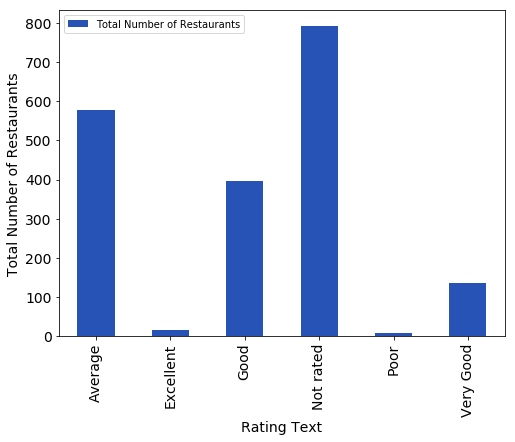

```python
p = rating_dataset.plot.bar(x='rating_text', y='Total Number of Restaurants',figsize=(8,6),color='#2752B6',
fontsize=14)
p.set_xlabel("Rating Text",fontsize=14)
p.set_ylabel("Total Number of Restaurants",fontsize=14)
plt.show()
```

**Graph Insight**  
We can see from the above graph that lot of users have rated restaurants to be average or good and only a few have rated anything beyond that. Also there are many restaurants in the dataset that have not been rated.

## 5.2 Most Popular Restaurants in Dublin

```python
series=restaurants_dataset["restaurant_name"].value_counts().head(10)
popular_restaurants_df = pd.DataFrame(series).reset_index()
popular_restaurants_df.columns = ['Restaurant Name', 'Number of Restaurants']
popular_restaurants_df
```

|  | Restaurant Name | Number of Restaurants |
| --- | --- | --- |
| 0 | Subway | 29 |
| 1 | Eddie Rocket's | 20 |
| 2 | McDonald's | 19 |
| 3 | Abrakebabra | 13 |
| 4 | Butlers Chocolate Cafe | 10 |
| 5 | Domino's | 10 |
| 6 | Milano | 9 |
| 7 | Nando's | 9 |
| 8 | Thunders Bakery | 8 |
| 9 | Camile | 8 |

Plotting it in the form of wordcloud

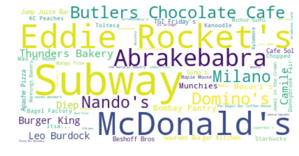

```python
counts=restaurants_dataset["restaurant_name"].value_counts()
counts.index = counts.index.map(str)
wordcloud = WordCloud(background_color='white',
                      max_font_size = 60,
                      collocations=False).generate_from_frequencies(counts)
plt.figure(figsize=(10,10))
plt.imshow(wordcloud, interpolation="bilinear")
plt.axis("off")
plt.show()
```

**Graph Insight**  
We can see from the above wordcloud that most popular restaurants in Dublin are Eddie Rocket, Subway, McDonald's. Or we can say restaurants with maximum outlets in Dublin

## 5.3 Analysis of Popular Cuisines in Dublin

```python
series=restaurants_cuisines_merged_df['cuisines'].value_counts().head(10)
popular_cuisines_df = pd.DataFrame(series).reset_index()
popular_cuisines_df.columns = ['Cuisine Name', 'Number of Restaurants']
popular_cuisines_df
```

|  | Cuisine Name | Number of Restaurants |
| --- | --- | --- |
| 0 | Asian | 217 |
| 1 | Cafe | 201 |
| 2 | Fast Food | 194 |
| 3 | Irish | 141 |
| 4 | Chinese | 116 |
| 5 | Pub Food | 101 |
| 6 | Drinks Only | 100 |
| 7 | Cafe | 100 |
| 8 | Indian | 98 |
| 9 | Pizza | 85 |

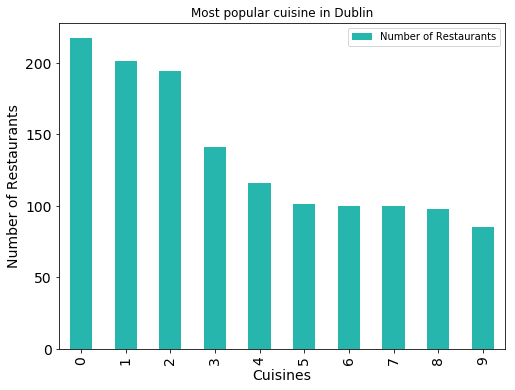

```python
p = popular_cuisines_df.plot.bar(figsize=(8,6),
fontsize=14,title ='Most popular cuisine in Dublin',color='#27B6AD')
p.set_xlabel("Cuisines",fontsize=14)
p.set_ylabel("Number of Restaurants",fontsize=14)
plt.show()
```

From the above graph we can see the most popular cuisines in Dublin

## 5.4 Analysis of Average Cost for Two People

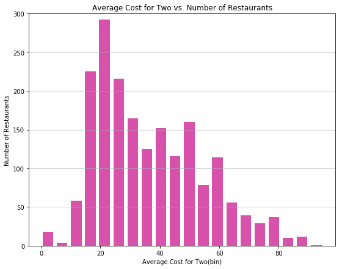

```python
# Set figure width to 12 and height to 9
fig_size = plt.rcParams["figure.figsize"]
fig_size[0] = 9
fig_size[1] = 7
plt.rcParams["figure.figsize"] = fig_size
s=restaurants_dataset[restaurants_dataset['average_cost_for_two'] <100]
n, bins, patches = plt.hist(x=s['average_cost_for_two'], bins='auto', color='#CF2797',
                            alpha=0.8, rwidth=0.75)
plt.grid(axis='y', alpha=0.75)
plt.xlabel('Average Cost for Two(bin)')
plt.ylabel('Number of Restaurants')
plt.title('Average Cost for Two vs. Number of Restaurants')
maxfreq = n.max()
# Set a clean upper y-axis limit.
plt.ylim(top=np.ceil(maxfreq / 10) * 10 if maxfreq % 10 else maxfreq + 10)
plt.show()
```

**Graph Insight**  
We can see from the above graph that maximum number of restaurants have average cost for two between 15-30 euro. There are very few restaurants which have average cost for two more than 80 euro. Also there are very few restaurants with average cost for two less than 10 euro

## 5.5 Finding localities with maximum number of restaurants

```python
restaurants_count_by_locality= restaurants_dataset['locality'].value_counts().head(10)
restaurants_count_by_locality_df = pd.DataFrame(restaurants_count_by_locality).reset_index()
restaurants_count_by_locality_df.columns = ['Locality', 'Number of Restaurants']
restaurants_count_by_locality_df
```

|  | Locality | Number of Restaurants |
| --- | --- | --- |
| 0 | South City West | 254 |
| 1 | South City East | 187 |
| 2 | North City | 144 |
| 3 | Temple Bar | 101 |
| 4 | Ballsbridge | 50 |
| 5 | Malahide | 38 |
| 6 | Ranelagh | 37 |
| 7 | Drumcondra | 30 |
| 8 | Swords | 29 |
| 9 | Howth | 29 |

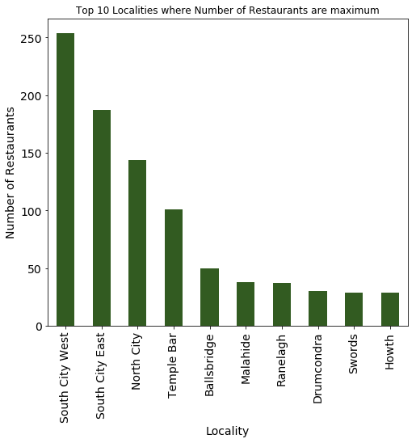

```python
plot = restaurants_count_by_locality.plot.bar(figsize=(8,7), color='#325B21',
fontsize=14, title='Top 10 Localities where Number of Restaurants are maximum')
plot.set_xlabel("Locality",fontsize=14)
plot.set_ylabel("Number of Restaurants",fontsize=14)
plt.show()
```

**Graph Insight**  
From the above graph we can see the localities/areas in Dublin where we have more number of restaurants as compared to other places

## 5.6 Finding Zipcodes where we have maximum number of restaurants

```python
restaurants_count_by_zipcode=restaurants_dataset["zipcode"].value_counts().head(10)
restaurants_count_by_zipcode_df = pd.DataFrame(restaurants_count_by_zipcode).reset_index()
restaurants_count_by_zipcode_df.columns = ['Zipcode', 'Number of Restaurants']
restaurants_count_by_zipcode_df
```

|  | Zipcode | Number of Restaurants |
| --- | --- | --- |
| 0 | Dublin 2 | 561 |
| 1 | Not Available | 402 |
| 2 | Dublin 1 | 198 |
| 3 | Dublin 6 | 95 |
| 4 | Dublin 4 | 90 |
| 5 | Dublin 8 | 63 |
| 6 | Dublin 9 | 63 |
| 7 | Dublin 15 | 59 |
| 8 | Dublin 7 | 54 |
| 9 | Dublin 14 | 40 |

We can ignore the rows whose zipcode value is not available

```python
restaurants_count_by_zipcode=restaurants_dataset[restaurants_dataset["zipcode"] != 'Not Available'].zipcode.value_counts().head(10)
restaurants_count_by_zipcode_df = pd.DataFrame(restaurants_count_by_zipcode).reset_index()
restaurants_count_by_zipcode_df.columns = ['Zipcode', 'Number of Restaurants']
restaurants_count_by_zipcode_df
```

|  | Zipcode | Number of Restaurants |
| --- | --- | --- |
| 0 | Dublin 2 | 561 |
| 1 | Dublin 1 | 198 |
| 2 | Dublin 6 | 95 |
| 3 | Dublin 4 | 90 |
| 4 | Dublin 8 | 63 |
| 5 | Dublin 9 | 63 |
| 6 | Dublin 15 | 59 |
| 7 | Dublin 7 | 54 |
| 8 | Dublin 24 | 40 |
| 9 | Dublin 14 | 40 |

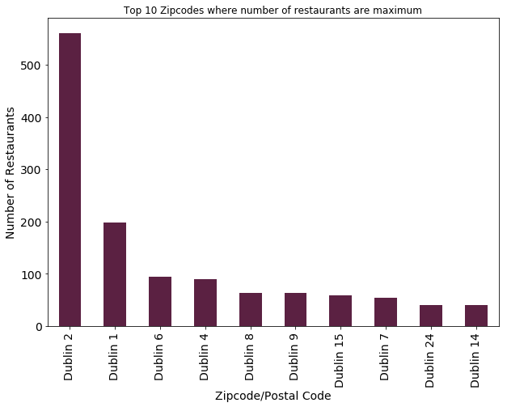

```python
plot = restaurants_count_by_zipcode.plot.bar(figsize=(10,7),
fontsize=14, title='Top 10 Zipcodes where number of restaurants are maximum',color='#5B2142')
plot.set_xlabel("Zipcode/Postal Code",fontsize=14)
plot.set_ylabel("Number of Restaurants",fontsize=14)
plt.show()
```

**Graph Insight**  
From the above graph we can see the area codes in Dublin where we have more number of restaurants as compared to other places. Dublin 2 has maximum number of restaurants

## 5.7 Locality v/s Rating

In this we are trying to analyse the different rating for top ten popular localities.

```python
restaurants_count_by_locality= restaurants_dataset['locality'].value_counts().head(10)
s=restaurants_dataset[restaurants_dataset.locality.isin(restaurants_count_by_locality.index)]
df_agg = s.groupby(['locality','rating_text']).agg('count')['restaurant_id']
dfa=df_agg.unstack(level=1)
```

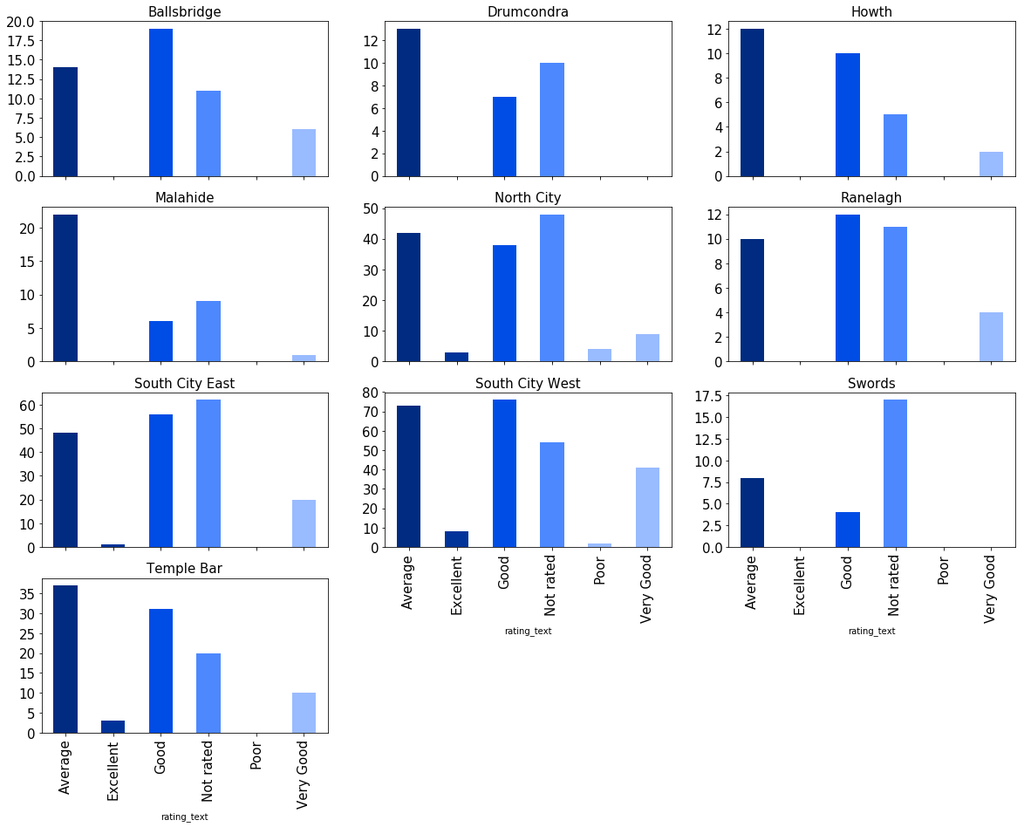

```python
fig = plt.figure(figsize=(20,15))
count=1
color=['#002b80','#003399','#004de6','#4d88ff','#99bbff','#99bbff']
for index, row in dfa.iterrows():
    ax = fig.add_subplot(4, 3, count)
    row.plot(kind='bar',title=index,sharex=True,fontsize=15,color=color)
    ax.title.set_size(15)
    count=count+1

plt.show()
```

**Graph Insight**  
We can see from the above graph that there are only few restaurants which have excellent rating and most of then are in Temple Bar and South City West Region. All other regions have most of the rating as Average or Good. Also there are many restaurants in each region which have not been rated. In swords, most of the restaurants are not rated. On the other hand in Howth, number of restaurants which are not rated are less.

## 5.8 Cuisines v/s Rating

In this we are trying to analyse the different rating for popular cuisines in Dublin

```python
cuisines_count=restaurants_cuisines_merged_df['cuisines'].value_counts().head(10)
s=restaurants_cuisines_merged_df[restaurants_cuisines_merged_df.cuisines.isin(cuisines_count.index)]
df_agg = s.groupby(['cuisines','rating_text']).agg('count')['restaurant_id']
```

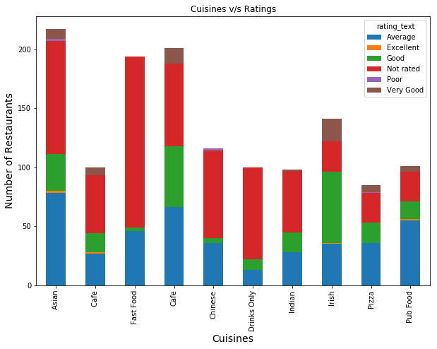

```python
plot=df_agg.unstack(level=1).plot(kind='bar', stacked=True,title='Cuisines v/s Ratings',figsize=(10,7))
plot.set_xlabel("Cuisines",fontsize=14)
plot.set_ylabel("Number of Restaurants",fontsize=14)
plt.show()
```

## 5.9 Relation Between Aggregate rating and Average cost for two

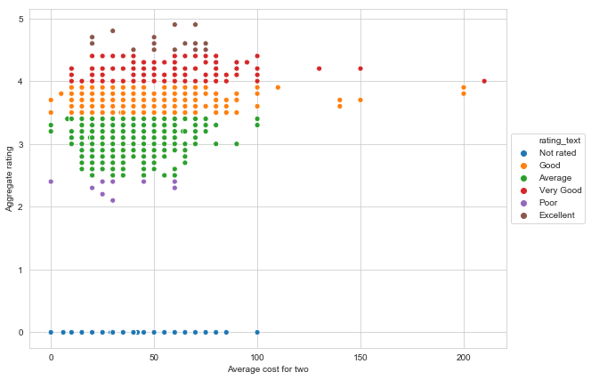

```python
sns.set_style("whitegrid")
plt.figure(figsize=(12,7))
ax = sns.scatterplot(y="aggregate_rating", x="average_cost_for_two",
                      hue="rating_text", data=restaurants_dataset)


box = ax.get_position()
ax.set_position([box.x0, box.y0, box.width * 0.8, box.height])

# Put a legend to the right of the current axis
ax.legend(loc='center left', bbox_to_anchor=(1, 0.5))

ax.set_xlabel("Average cost for two")
ax.set_ylabel("Aggregate rating")
plt.show()
```

**Graph Insight**  
In the above graph, we can see that there is no relation between average cost for two and Aggregate Rating. Most of the restaurants have average cost for two between 15-75 euro. And in that range we have all kind of ratings. Most of the rating are between 3 and 4 which corresponds to Average and Good

## 5.10 Analysis of Popular Highlights of Restaurants in Dublin

```python
series=restaurants_feature_merged_df[restaurants_feature_merged_df['Present/NotPresent'] == 'Present'].Highlights.value_counts().head(5)
popular_highlights_df = pd.DataFrame(series).reset_index()
popular_highlights_df.columns = ['Highlight Name', 'Number of Restaurants']
popular_highlights_df
```

|  | Highlight Name | Number of Restaurants |
| --- | --- | --- |
| 0 | Indoor Seating | 1343 |
| 1 | Takeaway Available | 1073 |
| 2 | Wifi | 899 |
| 3 | Full Bar Available | 615 |
| 4 | Breakfast | 606 |

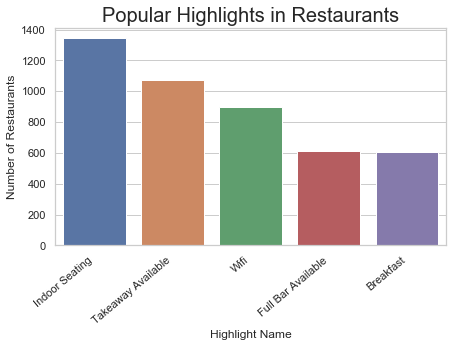

```python
plt.figure(figsize=(7,4))
sns.set(style="whitegrid")
ax = sns.barplot(x="Highlight Name", y="Number of Restaurants", data=popular_highlights_df)
ax.set_xticklabels(ax.get_xticklabels(), rotation=40, ha="right")
ax.set_title("Popular Highlights in Restaurants",fontsize=20)
plt.show()
```

**Graph Insight**  
We can see from the above graph that most of the restaurants in Dublin have Indoor Seating, Takeaway facility, Wifi, Bar and Breakfast option

## 5.11 Analysis of Popular Area's for Takeaway in Dublin

```python
series=restaurants_feature_merged_df[restaurants_feature_merged_df.Highlights == 'Takeaway Available'].\
                groupby("locality").agg('count')['restaurant_id'].nlargest(10)


takeaway_localities_df = pd.DataFrame(series).reset_index()
takeaway_localities_df.columns = ['Locality Name', 'Number of Restaurants']
takeaway_localities_df
```

|  | Locality Name | Number of Restaurants |
| --- | --- | --- |
| 0 | South City West | 130 |
| 1 | South City East | 84 |
| 2 | North City | 82 |
| 3 | Temple Bar | 42 |
| 4 | Ballsbridge | 30 |
| 5 | Malahide | 26 |
| 6 | Dun Laoghaire | 22 |
| 7 | Drumcondra | 18 |
| 8 | Ranelagh | 18 |
| 9 | Rathmines | 18 |

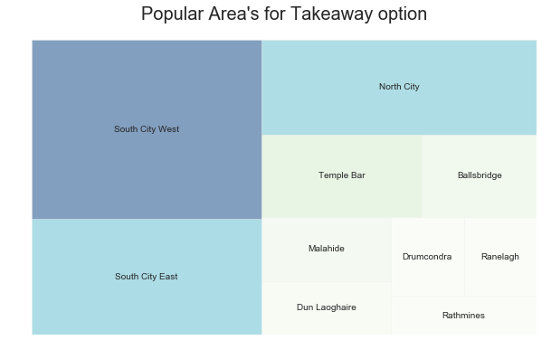

```python
style.use('ggplot')
fig, ax = plt.subplots(figsize=(10,6))
# Colormap
cmap = matplotlib.cm.GnBu
# Min and Max Values
mini = min(takeaway_localities_df["Number of Restaurants"])
maxi = max(takeaway_localities_df["Number of Restaurants"])
# Finding Colors for each tile
norm = matplotlib.colors.Normalize(vmin=mini, vmax=maxi)
colors = [cmap(norm(value)) for value in takeaway_localities_df["Number of Restaurants"]]
# Plotting
squarify.plot(sizes=takeaway_localities_df["Number of Restaurants"], label=takeaway_localities_df["Locality Name"],\
              alpha=0.5, color=colors)
# Removing Axis
plt.axis('off')
plt.gca().invert_yaxis()
plt.title("Popular Area's for Takeaway option", fontsize=20)
ttl = ax.title
ttl.set_position([.5, 1.05])
```

## 5.12 Analysis of Popular Area's for Nightlife in Dublin

```python
series=restaurants_feature_merged_df[restaurants_feature_merged_df.Highlights == 'Nightlife'].\
                groupby("locality").agg('count')['restaurant_id'].nlargest(10)


nightlife_localities_df = pd.DataFrame(series).reset_index()
nightlife_localities_df.columns = ['Locality Name', 'Number of Restaurants']
nightlife_localities_df
```

|  | Locality Name | Number of Restaurants |
| --- | --- | --- |
| 0 | South City West | 73 |
| 1 | South City East | 51 |
| 2 | North City | 36 |
| 3 | Temple Bar | 30 |
| 4 | Ballsbridge | 12 |
| 5 | Swords | 9 |
| 6 | Dalkey | 7 |
| 7 | Drumcondra | 6 |
| 8 | Glasnevin | 6 |
| 9 | Ranelagh | 6 |

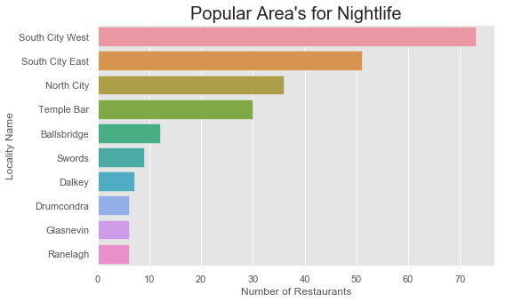

```python
plt.figure(figsize=(8,5))
ax = sns.barplot(x="Number of Restaurants", y="Locality Name", data=nightlife_localities_df)
ax.set_title("Popular Area's for Nightlife", fontsize=20)
```

## 5.13 Analysis of Popular Area's for Breakfast in Dublin

```python
series=restaurants_feature_merged_df[restaurants_feature_merged_df.Highlights == 'Breakfast'].\
                groupby("locality").agg('count')['restaurant_id'].nlargest(10)
breakfast_localities_df = pd.DataFrame(series).reset_index()
breakfast_localities_df.columns = ['Locality Name', 'Number of Restaurants']
breakfast_localities_df
```

|  | Locality Name | Number of Restaurants |
| --- | --- | --- |
| 0 | South City East | 81 |
| 1 | South City West | 69 |
| 2 | North City | 46 |
| 3 | Ballsbridge | 21 |
| 4 | Temple Bar | 16 |
| 5 | Malahide | 14 |
| 6 | Ranelagh | 12 |
| 7 | Blanchardstown Shopping Centre, Blanchardstown | 11 |
| 8 | Drumcondra | 10 |
| 9 | Howth | 10 |

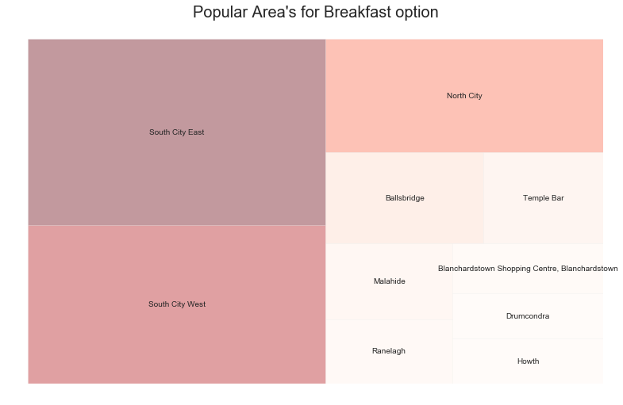

```python
style.use('ggplot')
fig, ax = plt.subplots(figsize=(13,8))
# Colormap
cmap = matplotlib.cm.Reds
# Min and Max Values
mini = min(breakfast_localities_df["Number of Restaurants"])
maxi = max(breakfast_localities_df["Number of Restaurants"])
# Finding Colors for each tile
norm = matplotlib.colors.Normalize(vmin=mini, vmax=maxi)
colors = [cmap(norm(value)) for value in breakfast_localities_df["Number of Restaurants"]]
# Plotting
squarify.plot(sizes=breakfast_localities_df["Number of Restaurants"], label=breakfast_localities_df["Locality Name"],\
              alpha=0.4, color=colors)
# Removing Axis
plt.axis('off')
plt.gca().invert_yaxis()
plt.title("Popular Area's for Breakfast option", fontsize=20)
ttl = ax.title
ttl.set_position([.5, 1.05])
```

## 5.14 Finding popular highlights which are present in restaurants whose rating are Good, Very Good and Excellent

```python
highlight_df= restaurants_feature_merged_df[restaurants_feature_merged_df.rating_text.isin(['Good','Very Good','Excellent'])]
highlight_df=highlight_df[highlight_df['Present/NotPresent'] == 'Present'].Highlights.value_counts().head(5)


highlight_df = pd.DataFrame(highlight_df).reset_index()
highlight_df.columns = ['Highlight Name', 'Number of Restaurants']
highlight_df
```

|  | Highlight Name | Number of Restaurants |
| --- | --- | --- |
| 0 | Indoor Seating | 422 |
| 1 | Wifi | 306 |
| 2 | Full Bar Available | 253 |
| 3 | Takeaway Available | 241 |
| 4 | Lunch Menu | 214 |

**Table Insight**  
From the above table we can see that restaurants with above average rating have Indoor Seating, Wifi, Full Bar Available, Takeaway Available and Lunch Menu options

## 5.15 Finding popular highlights which are not present in restaurants whose rating are Poor

```python
highlight_df_poor= restaurants_feature_merged_df[restaurants_feature_merged_df.rating_text.isin(['Poor'])]
highlight_df_poor=highlight_df_poor[highlight_df_poor['Present/NotPresent'] == 'Not Present'].Highlights.value_counts().head(5)
highlight_df_poor = pd.DataFrame(highlight_df_poor).reset_index()
highlight_df_poor.columns = ['Highlight Name', 'Number of Restaurants']
highlight_df_poor
```

|  | Highlight Name | Number of Restaurants |
| --- | --- | --- |
| 0 | No Takeaway | 6 |
| 1 | No Alcohol Available | 1 |

**Table Insight**  
The above table shows that **Takeaway and Alcohol Availability** are two important factors for good rating. Restuarants which have Average and above rating have these facilities

## 5.16 Analysing the Sentiment of Reviews

```python
sentiment_series=restaurants_review_merged_df.sentiment.value_counts()
sentiment_df = pd.DataFrame(sentiment_series).reset_index()
sentiment_df.columns = ['Sentiment', 'Number of Reviews']
sentiment_df
```

|  | Sentiment | Number of Reviews |
| --- | --- | --- |
| 0 | Positive | 4423 |
| 1 | Neutral | 559 |
| 2 | Negative | 481 |

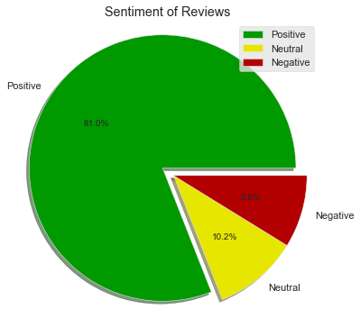

```python
labels = sentiment_df['Sentiment']
sizes = sentiment_df['Number of Reviews']
explode = (0.1, 0, 0)
colors = ['#009900', '#e6e600', '#b30000']


fig1, ax1 = plt.subplots(figsize=(6,6))
ax1.pie(sizes, explode=explode, colors=colors,labels=labels, autopct='%1.1f%%',
        shadow=True)
plt.title('Sentiment of Reviews')
ax1.axis('equal')
plt.legend(labels,loc=1)
plt.show()
```

**Graph Insight**  
We can see from the above graph that most of the reviews are positive. Only few reviews are Negative or Neutral

## 5.17 Analysing the Sentiment of Reviews on the basis of top ten popular Localities

```python
restaurants_count_by_locality= restaurants_dataset['locality'].value_counts().head(10)
s=restaurants_review_merged_df[restaurants_review_merged_df.locality.isin(restaurants_count_by_locality.index)]
df_agg=s.groupby(['locality','sentiment']).agg('count')['restaurant_id']
dfa=df_agg.unstack(level=1)
dfa
```

| sentiment locality | Negative | Neutral | Positive |
| --- | --- | --- | --- |
| Ballsbridge | 12 | 19 | 153 |
| Drumcondra | 7 | 16 | 79 |
| Howth | 8 | 11 | 98 |
| Malahide | 7 | 8 | 102 |
| North City | 38 | 59 | 363 |
| Ranelagh | 8 | 13 | 114 |
| South City East | 52 | 66 | 497 |
| South City West | 78 | 116 | 733 |
| Swords | 3 | 7 | 45 |
| Temple Bar | 27 | 42 | 298 |

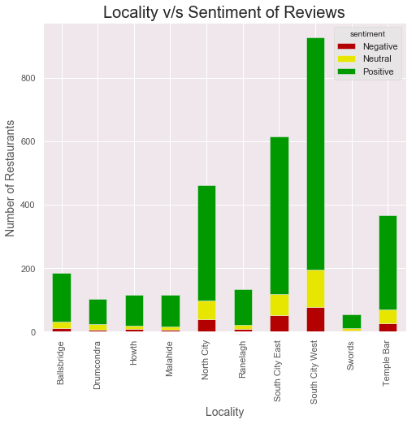

```python
color=['#b30000','#e6e600','#009900']
plot=dfa.plot(kind='bar', stacked=True,figsize=(8,7),color=color)
plot.set_xlabel("Locality",fontsize=14)
plot.set_ylabel("Number of Restaurants",fontsize=14)
plot.set_title("Locality v/s Sentiment of Reviews",fontsize=20)
plot.set_facecolor('#EFE7EB')
```

## 5.18 Distribution of Aggregate Rating According to Sentiments

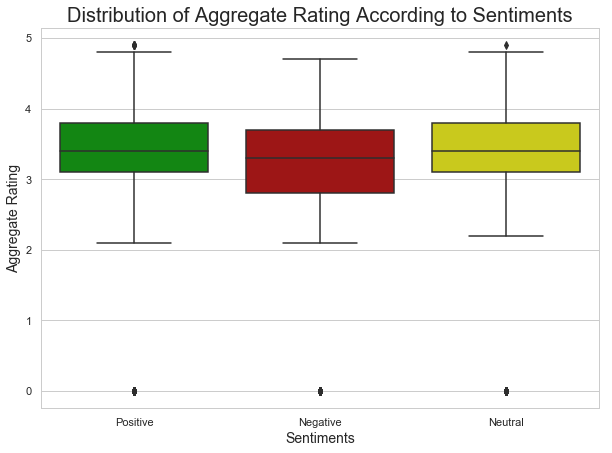

```python
x=restaurants_review_merged_df.sentiment
y=restaurants_review_merged_df.aggregate_rating.astype(float)
sns.set_style("whitegrid")
my_pal = {"Positive": "#009900", "Negative": "#b30000", "Neutral":"#e6e600"}
plt.subplots(figsize=(10,7))
ax = sns.boxplot(x=x, y=y,palette=my_pal)
ax.set_title('Distribution of Aggregate Rating According to Sentiments',fontsize=20)
ax.set_ylabel('Aggregate Rating',fontsize=14)
ax.set_xlabel('Sentiments',fontsize=14)
plt.show()
```

**Graph Insight**  
We can see from the above graph that most of the positive reviews have aggreagte rating between 3.2 -3.8. Maximum rating for positive review is around 4.8 and minimum as 2.1. For negative reviews, fifty percent of the aggreagte rating is between 2.8- 3.6. For Neutral reviews, maximum ratings are between 3.1 - 3.7. This result can be because of the limitation of Zomato API. We only get first 150 charaters of the review. If we get full review, then we can get more accurate data. But in general we can see that Positive Review have better aggregate rating than Negative reviews

## 5.19 Analysing the Sentiment of Reviews on the basis Foodie Level of users

```python
df_agg=restaurants_review_merged_df.groupby(['user_foodie_level','sentiment']).agg('count')['restaurant_id']
dfa=df_agg.unstack(level=1)
dfa
```

| sentiment user_foodie_level | Negative | Neutral | Positive |
| --- | --- | --- | --- |
| Big Foodie | 171 | 212 | 1668 |
| Connoisseur | 16 | 39 | 216 |
| Foodie | 181 | 120 | 964 |
| Super Foodie | 113 | 188 | 1575 |

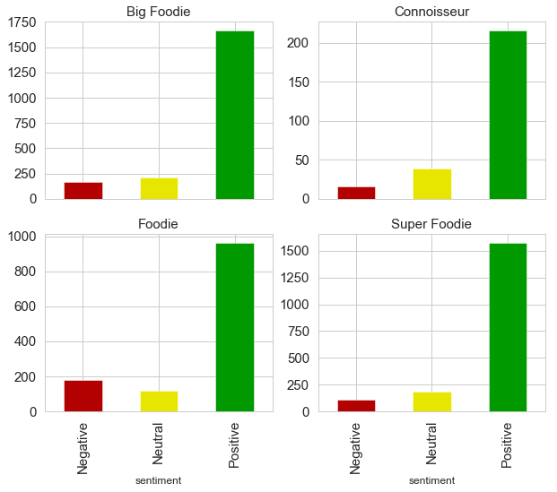

```python
fig = plt.figure(figsize=(10,8))
count=1
color=['#b30000','#e6e600','#009900']
for index, row in dfa.iterrows():
    ax = fig.add_subplot(2, 2, count)
    row.plot(kind='bar',title=index,sharex=True,fontsize=15,color=color)
    ax.title.set_size(15)
    count=count+1
```

**Graph Insight**  
We can see from the above graph that all Foodie Level of users gives majority of positive reviews.Foodie and Big Foodie gives more negative reviews than Connoisseur or Super Foodie users.

## 5.20 Analysing the Sentiment of Reviews on the basis of Popular Cuisines

```python
cuisines_review_df = pd.merge(restaurants_cuisines_merged_df, restaurants_review_merged_df, how='inner', on = 'restaurant_id')
cuisines_count=restaurants_cuisines_merged_df['cuisines'].value_counts().head(10)
df_agg=cuisines_review_df[cuisines_review_df.cuisines_x.isin(cuisines_count.index)].groupby(['cuisines_x','sentiment']).agg('count')['restaurant_id']
df_unstack=df_agg.unstack(level=1)
df_unstack
```

| sentiment cuisines_x | Negative | Neutral | Positive |
| --- | --- | --- | --- |
| Asian | 61 | 53 | 441 |
| Cafe | 23 | 40 | 236 |
| Fast Food | 36 | 34 | 218 |
| Cafe | 56 | 54 | 558 |
| Chinese | 39 | 23 | 152 |
| Drinks Only | 13 | 14 | 101 |
| Indian | 19 | 24 | 184 |
| Irish | 31 | 60 | 437 |
| Pizza | 30 | 24 | 222 |
| Pub Food | 27 | 36 | 254 |

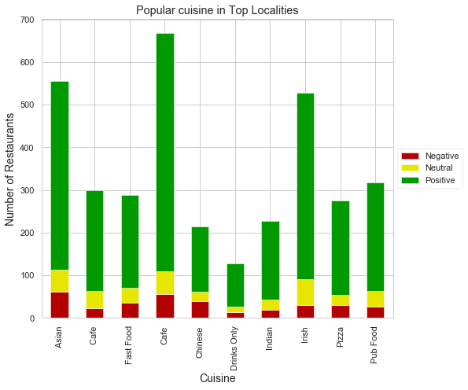

```python
color=['#b30000','#e6e600','#009900']
plot=df_unstack.plot(kind='bar', stacked=True,title='Popular cuisine in Top Localities',figsize=(10,7),color=color)
plot.set_xlabel("Cuisine",fontsize=14)
plot.set_ylabel("Number of Restaurants",fontsize=14)
box = plot.get_position()
plot.set_position([box.x0, box.y0, box.width * 0.8, box.height])
plot.legend(loc='center left', bbox_to_anchor=(1, 0.5))
plt.show()
```

**Graph Insight**  
We can see from the above graph that for all the top ten popular cuisines, reviews are positive Maximum number of negative reviews are for Asian Cuisine, followed by Cafe.

**Insights about Dublin restaurants from the Zomato dataset**

- **Popular Restaurants, Cuisines and Localities**
- Most popular restaurants in Dublin are Eddie Rocket, Subway and McDonald's (Graph 2)
- Most popular cuisines in Dublin are Asian, Cafe, Fast Food, Irish and Chinese (Graph 3)
- South City West, South City East, North City, Temple Bar and Ballsbridge have maximum number of restaurants in Dublin (Graph 5)
- **Rating of Restaurants**
- People have rated majority restaurants as “Average” or "Good". Only few restaurants have been rated as "Excellent". Also there are many restaurants that have not been rated (Graph 1)
- There are only few restaurants, which have “Excellent” rating, and most of then are in Temple Bar and South City West Region. All other regions have most of the rating as “Average” or “Good”. So we can say that Temple Bar and South City West Region has best restaurants in Dublin (Graph 7)
- The most sold cuisine is Asian cuisine but the highly rated cuisine is Irish cuisine (Graph 8)
- **Average Cost For Two**
- Most of the restaurants in Dublin have average cost for two, between 15 and 40 euro. There are very few restaurants, which have average cost for two more than 80 euro. Also there are very few restaurants with average cost for two less than 10 euro (Graph 4
- We saw that there is no relation between average cost for two and aggregate Rating. Most of the restaurants have average cost for two between 15 and 40 euro. And in that range we have all kind of ratings (Graph 9)
- **Analysis of Highlights/ Facilities Available in Restaurants**
- Most of the restaurants in Dublin have facilities like Indoor Seating, Takeaway facility, Wi-Fi, Bar and Breakfast option (Graph 10)
- South City West, South City East, North City, Temple Bar and Ballsbridge areas have maximum restaurants that provide Takeaway, Nightlife and Breakfast option (Graph 11, 12, 13)
- We saw that restaurants with above average rating have Indoor Seating, Wi-Fi, Full Bar Available, Takeaway Available and Lunch Menu options (Table 14)
- We saw that restaurants with Poor rating don’t have takeaway option and alcohol availability. Restaurants that have Average and above rating have these facilities. So these options plays an important role in determining the rating (Table 15)
- **Sentiment Analysis of Reviews**

Please Note that Zomato API has a restriction that only 5 reviews can be fetched for a particular restaurant. And also we get only first 150 characters of each review. So below analysis may be impacted because of it.

- By performing sentiment analysis on the reviews, we saw that majority of the reviews are positive. And only few restaurants have negative or neutral review. This finding was also seen in Graph 1 where we were analysing the rating of users. We saw that most of the users have rated restaurants as either “Average” or “Good”, which means positive reviews. Only few restaurants have been rated as “Poor”. (Graph 16)
- We have also analysed reviews on the basis of top ten popular localities. Reviews are mostly positive there. In South City West, we have few restaurants with neutral or negative reviews. Otherwise mostly have positive review. This finding was also seen while we were analysing rating on the basis of localities (Graph 7). (Graph 17)
- We also analysed the relation between sentiment of reviews and aggregate rating. From the graph we saw that most of the positive reviews have aggregate rating between 3.2 -3.8. For negative reviews, fifty percent of the aggregate rating is between 2.8- 3.6. For Neutral reviews, maximum ratings are between 3.1 - 3.7. If we get full reviews, then we can get more accurate data. But in general we can see that Positive Review have better aggregate rating than Negative reviews (Graph 18)
- We also analysed the sentiments of reviews on the basis of Foodie Level of users. All Foodie Level of users gives majority of positive reviews. Foodie and Big Foodie gives more negative reviews than Connoisseur or Super Foodie users (Graph 19)

**For Reference**

- Graph 1- Analysis of Restaurants Rating
- Graph 2- Most Popular Restaurants in Dublin
- Graph 3- Analysis of Popular Cuisines in Dublin
- Graph 4- Analysis of Average Cost for Two People
- Graph 5- Finding localities with maximum number of restaurants
- Graph 6- Finding Zip codes where we have maximum number of restaurants
- Graph 7- Locality v/s Rating
- Graph 8-Cuisines v/s Rating
- Graph 9- Relation Between Aggregate rating and Average cost for two
- Graph 10- Analysis of Popular Highlights of Restaurants in Dublin
- Graph 11- Analysis of Popular Area's for Takeaway in Dublin
- Graph 12- Analysis of Popular Area's for Nightlife in Dublin
- Graph 13- Analysis of Popular Area's for Breakfast in Dublin
- Graph 14- Finding popular highlights which are present in restaurants whose rating are Good, Very Good and Excellent
- Graph 15- Finding popular highlights which are not present in restaurants whose rating are Poor
- Graph 16- Analysing the Sentiment of Reviews
- Graph 17- Analysing the Sentiment of Reviews on the basis of top ten popular Localities
- Graph 18 - Distribution of Aggregate Rating According to Sentiments
- Graph 19- Analysing the Sentiment of Reviews on the basis Foodie Level of users
- Graph 20- Analysing the Sentiment of Reviews on the basis of Popular Cuisines